# TidyTuesday 2022: Week 1

Better late than never… this [#TidyTuesday](https://github.com/rfordatascience/tidytuesday) was bring your own data week.

I decided I’d try to get a rough estimate of the number of virtuoso violinists (raw and per capita) have come from each country.

I couldn’t find a very reliable data source, so I decided to use the number of individual Wikipedia pages as a proxy. If you check out the [Category:Classical violinists by nationality](https://en.wikipedia.org/wiki/Category:Classical_violinists_by_nationality) on Wikipedia, you’ll get a list of countries and a number for how many individual pages (one for each player) exist for that country. (Note that the English view seemed to have the most data, so I used that one.)

I then fetched world population data for the countries listed from [Worldometer](https://www.worldometers.info/world-population/population-by-country/)’s population estimates (2022). (Of course, this is a bit misleading because many of the violinists listed are not currently alive, but hey, this is an exercise…)

For the populations of England, Scotland, Wales (all 2019), and the USSR (1989) I used Wikipedia once again.

A couple things to note:

- There are three subcategories under British classical violinists: English, Scottish, and Welsh violinists. It appears that individuals are filed either under one of those three *or* as British (N = 45). I decided to use only the numbers under the subcategories, to avoid confusion.
- French violinists are filed under three subcategories: 20th-century violinists, male violinists, and female violinists, each with their own sub-categories. I decided to combine the numbers of all pages under male and female violinists.
1. Load Data

```r
library(tidyverse)
library(extrafont) # extra fonts
#font_import() # if it's the first time using extrafont
loadfonts(device = "win", quiet = TRUE)
library(ggthemes) # for playing around with, for example
# theme_economist()
# theme_fivethirtyeight()
# theme_wsj()

data <- readxl::read_excel("2022Week1_violinists.xlsx")
head(data)
```

| country | violinists | population (mil) | year | source |
| --- | --- | --- | --- | --- |
| America | 275 | 331.0 | 2021 | Worldometer |
| Armenia | 11 | 2.9 | 2021 | Worldometer |
| Australia | 46 | 25.5 | 2021 | Worldometer |
| Austria | 74 | 9.0 | 2021 | Worldometer |
| Belgium | 40 | 11.6 | 2021 | Worldometer |
| Bolivia | 1 | 11.7 | 2021 | Worldometer |

2. Wrangle

```r
data <- data %>% mutate(percap = (violinists/`population (mil)`))

base <- data %>% arrange(desc(violinists))
percap <- data %>% arrange(desc(percap), desc(violinists))

head(base, 10)
```

| country | violinists | population (mil) | year | source | percap |
| --- | --- | --- | --- | --- | --- |
| America | 275 | 331.0 | 2021 | Worldometer | 0.8308157 |
| France | 224 | 65.3 | 2021 | Worldometer | 3.4303216 |
| Germany | 204 | 83.8 | 2021 | Worldometer | 2.4343675 |
| Canada | 115 | 37.7 | 2021 | Worldometer | 3.0503979 |
| Italy | 103 | 60.5 | 2021 | Worldometer | 1.7024793 |
| Hungary | 75 | 9.7 | 2021 | Worldometer | 7.7319588 |
| Austria | 74 | 9.0 | 2021 | Worldometer | 8.2222222 |
| England | 72 | 56.3 | 2019 | Wikipedia | 1.2788632 |
| Russia | 63 | 145.9 | 2021 | Worldometer | 0.4318026 |
| Czech | 52 | 10.7 | 2021 | Worldometer | 4.8598131 |

```r
head(percap, 10)
```

| country | violinists | population (mil) | year | source | percap |
| --- | --- | --- | --- | --- | --- |
| China | 15 | 1.4 | 2021 | Worldometer | 10.714286 |
| Austria | 74 | 9.0 | 2021 | Worldometer | 8.222222 |
| Hungary | 75 | 9.7 | 2021 | Worldometer | 7.731959 |
| Slovenia | 10 | 2.0 | 2021 | Worldometer | 5.000000 |
| Czech | 52 | 10.7 | 2021 | Worldometer | 4.859813 |
| Denmark | 26 | 5.8 | 2021 | Worldometer | 4.482759 |
| Norway | 24 | 5.4 | 2021 | Worldometer | 4.444444 |
| Armenia | 11 | 2.9 | 2021 | Worldometer | 3.793103 |
| Belgium | 40 | 11.6 | 2021 | Worldometer | 3.448276 |
| France | 224 | 65.3 | 2021 | Worldometer | 3.430322 |

3. Plot N Violinists per country

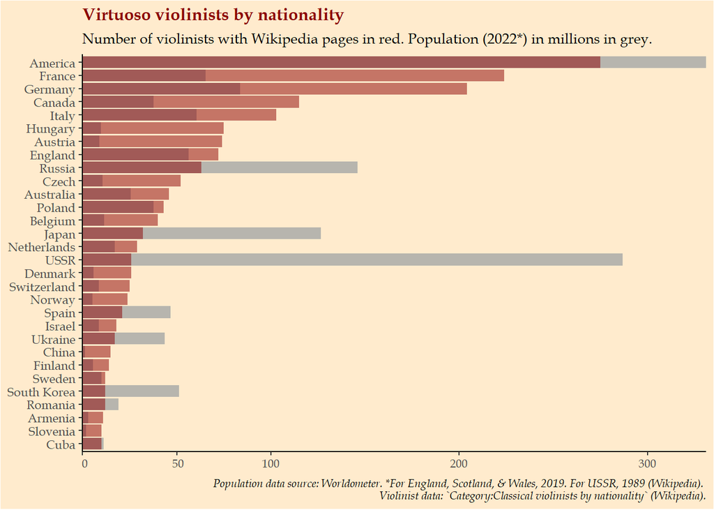

```r
p1 <- ggplot(base[1:30, ]) +
  geom_col( aes(fct_reorder(country,
                         violinists), `population (mil)`), fill = "slategray", alpha = 0.5) +
  geom_col( aes(fct_reorder(country,
                         violinists), violinists), fill = "red4" , alpha = 0.5 ) +
  #geom_point( aes(fct_reorder(country,
  #                       violinists), percap), fill = "darkblue" , alpha = 0.5 ) +
  theme_classic() +
  ggtitle("Virtuoso violinists by nationality",
          subtitle = "Number of violinists with Wikipedia pages in red. Population (2022*) in millions in grey.") +
  labs(x = NULL, y = NULL,
       caption = "Population data source: Worldometer. *For England, Scotland, & Wales, 2019. For USSR, 1989 (Wikipedia).
       Violinist data: `Category:Classical violinists by nationality` (Wikipedia).") +
  scale_y_discrete(limits = c(0, 50, 100, 200, 300), expand = c(0, 0)) +
  coord_flip() +
  theme(text = element_text(family="Book Antiqua"),
        panel.background = element_rect(fill = "blanchedalmond"),
        plot.background = element_rect(fill = "blanchedalmond"),
        plot.title = element_text(face = "bold", size = 12, color = "darkred"),
        plot.subtitle = element_text(size = 10),
        plot.caption = element_text(face = "italic", size = 8),
        axis.text.x = element_text(size = 8))

p1
```

4. Plot per capita violinists

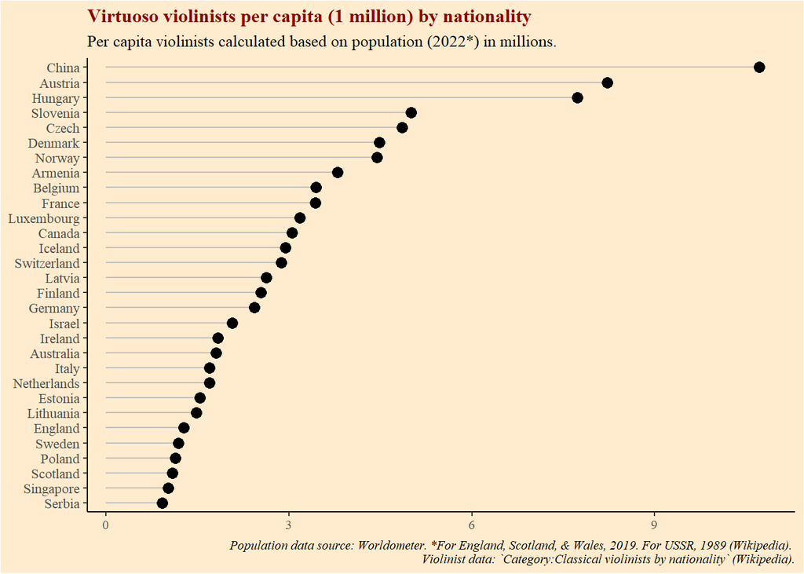

```r
p2 <- ggplot(percap[1:30,], aes(x = reorder(country, percap), y = percap)) +
  geom_segment(aes(y = 0, xend = country, yend = percap, group = country), color = "grey") +
  geom_point(color = "black", size = 3) +
  theme_classic() +
  ggtitle("Virtuoso violinists per capita (1 million) by nationality",
          subtitle = "Per capita violinists calculated based on population (2022*) in millions.") +
  labs(x = NULL, y = NULL,
       caption = "Population data source: Worldometer. *For England, Scotland, & Wales, 2019. For USSR, 1989 (Wikipedia).
       Violinist data: `Category:Classical violinists by nationality` (Wikipedia).") +
  scale_y_continuous(limits = c(0,11), expand = c(0, 0.3)) +
  coord_flip() +
  theme(text = element_text(family="Times New Roman"),
        panel.background = element_rect(fill = "blanchedalmond"),
        plot.background = element_rect(fill = "blanchedalmond"),
        plot.title = element_text(face = "bold", size = 12, color = "darkred"),
        plot.subtitle = element_text(size = 10),
        plot.caption = element_text(face = "italic", size = 8),
        axis.text.x = element_text(size = 8),
        legend.position = "none")

p2
```